# 2016 Primary Analysis

Amanda Dobbyn

September 24, 2016

# Overview

- About:
  - Data from [Kaggle](https://www.kaggle.com/datasets) can be found in `county_facts_abr.csv` and `primary_results.csv` and loaded in with whatever flavor of `read.csv` you prefer. Then you can pare down to the candidates treated here with `dplyr::filter()` or the base R alternative
  - More extensive code in `year_of_the_donald.R`
- Load data:
  - From a local PostgreSQL database
- Join the two datasets by county code
- Analyze:
  - Group counties into states and from there get vote totals/averages for candidates of interest
  - Pretend that this is a head to head in the general: look at total number of votes cast for Clinton and Trump
  - Using an “all-or-nothing” scheme, calculate the “winner” of each county and each state
- Model
  - Use demographic variables to train a random forest algorithm that predicts which general election candidate will “win” each county. Calculate the importance of each of these variables to the predictive power of the model
  - Train a K-nearest neighbors algorithm to do the same
- Plot:
  - Plot Clinton’s “lead” by state
  - Plot how various demographic variables affect vote outcomes for the candidates

# Load in and join datasets

Load in packages

```r
library(knitr)
library(RPostgreSQL)
library(tibble)
library(tidyr)
library(dplyr)   # remember, MASS::select and dplyr::select will mask each other
```

### Set up PostgreSQL connection

Read in 2016 presidential primary data from SQL database

- Set up driver as Postgres
- Set connection to our db

```r
drv <- dbDriver("PostgreSQL")

con <- dbConnect(drv, dbname="pullplay_db", host='localhost', port=5432, user="amanda")
```

Select all variables for the candidates Bernie, Trump, and Hillary

```r
primary_2016 <- dbGetQuery(con, "SELECT * FROM primary_2016
                           WHERE candidate in ('Bernie Sanders', 'Donald Trump', 'Hillary Clinton')")
```

### Manipulate variable types

Stick variables we want to make into factors in a vector

```r
to.factor <- c('state', 'state_abbr', 'county', 'party',
               'candidate')
```

Make those variables factors

```r
primary_2016[, to.factor] <- data.frame(apply(primary_2016[, to.factor], 2, as.factor))
```

Make `votes` numeric so we can do math on them

```r
primary_2016$votes <- as.numeric(primary_2016$votes)
```

Print structure and first few rows of the dataframe

```r
str(primary_2016)
```

```r
kable(head(primary_2016), format="markdown")
```

| id | state | state_abbr | county | fips_county_code | party | candidate | votes | fraction_votes |
| --- | --- | --- | --- | --- | --- | --- | --- | --- |
| 1 | Alabama | AL | Autauga | 1001 | Democrat | Bernie Sanders | 544 | 0.182 |
| 2 | Alabama | AL | Autauga | 1001 | Democrat | Hillary Clinton | 2387 | 0.800 |
| 3 | Alabama | AL | Baldwin | 1003 | Democrat | Bernie Sanders | 2694 | 0.329 |
| 4 | Alabama | AL | Baldwin | 1003 | Democrat | Hillary Clinton | 5290 | 0.647 |
| 5 | Alabama | AL | Barbour | 1005 | Democrat | Bernie Sanders | 222 | 0.078 |
| 6 | Alabama | AL | Barbour | 1005 | Democrat | Hillary Clinton | 2567 | 0.906 |

Make primary df into a tibble

```r
primary_2016 <- as_tibble(primary_2016)
```

Import county facts data from local database

```r
county_facts <- dbGetQuery(con, "SELECT * FROM county_facts")
```

Prepare like primary data

```r
to.fact <- c('area_name', 'state_abbreviation')
county_facts[, to.fact] <- data.frame(apply(county_facts[, to.fact], 2, as.factor))
county_facts <- as_tibble(county_facts)
```

Take a look

```r
str(county_facts)
```

```r
kable(head(county_facts), format="markdown")
```

| id | county_code | area_name | state_abbreviation | population_2014 | female | white | black | hispanic | college | inc_percap | inc_household |
| --- | --- | --- | --- | --- | --- | --- | --- | --- | --- | --- | --- |
| 1 | 0 | United States | NA | 318857056 | 50.8 | 77.4 | 13.2 | 17.4 | 28.8 | 28155 | 53046 |
| 2 | 1000 | Alabama | NA | 4849377 | 51.5 | 69.7 | 26.7 | 4.1 | 22.6 | 23680 | 43253 |
| 3 | 1001 | Autauga County | AL | 55395 | 51.4 | 77.9 | 18.7 | 2.7 | 20.9 | 24571 | 53682 |
| 4 | 1003 | Baldwin County | AL | 200111 | 51.2 | 87.1 | 9.6 | 4.6 | 27.7 | 26766 | 50221 |
| 5 | 1005 | Barbour County | AL | 26887 | 46.6 | 50.2 | 47.6 | 4.5 | 13.4 | 16829 | 32911 |
| 6 | 1007 | Bibb County | AL | 22506 | 45.9 | 76.3 | 22.1 | 2.1 | 12.1 | 17427 | 36447 |

### Join datasets

Take id out of county_facts so join() doesn’t join on id

```r
county <- county_facts %>%
  select (
    county_code,
    state_abbreviation, population_2014,
    female, white, black, hispanic, college,
    inc_percap, inc_household
  )
```

Inner join with primary data on county code to get our main dataset

```r
election <- primary_2016 %>%
  select(
    fips_county_code,
    state, state_abbr,
    party, candidate,
    votes, fraction_votes
  ) %>%
  inner_join(county, by = c("fips_county_code" = "county_code"))
```

Make election a tibble

```r
election <- as_tibble(election)
```

Examine our main dataframe

```r
str(election)
```

```r
kable(head(election), format="markdown")
```

| fips_county_code | state | state_abbr | party | candidate | votes | fraction_votes | state_abbreviation | population_2014 | female | white | black | hispanic | college | inc_percap | inc_household |
| --- | --- | --- | --- | --- | --- | --- | --- | --- | --- | --- | --- | --- | --- | --- | --- |
| 1001 | Alabama | AL | Democrat | Bernie Sanders | 544 | 0.182 | AL | 55395 | 51.4 | 77.9 | 18.7 | 2.7 | 20.9 | 24571 | 53682 |
| 1001 | Alabama | AL | Democrat | Hillary Clinton | 2387 | 0.800 | AL | 55395 | 51.4 | 77.9 | 18.7 | 2.7 | 20.9 | 24571 | 53682 |
| 1003 | Alabama | AL | Democrat | Bernie Sanders | 2694 | 0.329 | AL | 200111 | 51.2 | 87.1 | 9.6 | 4.6 | 27.7 | 26766 | 50221 |
| 1003 | Alabama | AL | Democrat | Hillary Clinton | 5290 | 0.647 | AL | 200111 | 51.2 | 87.1 | 9.6 | 4.6 | 27.7 | 26766 | 50221 |
| 1005 | Alabama | AL | Democrat | Bernie Sanders | 222 | 0.078 | AL | 26887 | 46.6 | 50.2 | 47.6 | 4.5 | 13.4 | 16829 | 32911 |
| 1005 | Alabama | AL | Democrat | Hillary Clinton | 2567 | 0.906 | AL | 26887 | 46.6 | 50.2 | 47.6 | 4.5 | 13.4 | 16829 | 32911 |

Make population and votes numeric

```r
election$population_2014 <- as.numeric(election$population_2014)
election$votes <- as.numeric(election$votes)
```

There are 51 levels of `state_abbreviation` (from `county_facts` data) and 49 levels of `state_abbr` (from `primary_2016` data)

See what the 2 level difference is

```r
setdiff(levels(election$state_abbreviation), levels(election$state_abbr))
```

```
## [1] "DC" "MN"
```

So we don’t have primary_2016 data from DC and MN

# Exploratory Analysis

- Manipulate election tibble to get a sense of the data

Make a window function to calculate state-wide averages per candidate while keeping county-wide counts as well

```r
e.window <- election %>%
  filter (
    candidate %in% c('Hillary Clinton', 'Donald Trump')
  ) %>%
  group_by(state_abbreviation, candidate) %>%
  mutate(
    n.counties = n(),
    w.b_gap = (white - black),
    state.fr.votes = mean(fraction_votes),
    state.percap = mean(inc_percap)
  ) %>%
  select (
    state_abbreviation, votes, fraction_votes, w.b_gap,       # these are county-wide
    n.counties, state.fr.votes, state.percap                  # these are state-wide
  ) %>%
  print(n = 10)
```

#### Democrats

First, only look at Bernie and Hillary

Get **average votes** per county per state (i.e., collapse across county)

```r
dems <- election %>%
  na.omit() %>%
  group_by(state, candidate) %>%
  filter(candidate %in% c('Bernie Sanders', 'Hillary Clinton')) %>%
  select(candidate, state, votes, fraction_votes) %>%
  summarise(
    avg_votes = mean(votes)
  )
```

Unstack the candidates

```r
dems.spread <- dems %>%
  spread (
    key = candidate,
    value = avg_votes
  )
kable(dems.spread, format = "markdown")
```

| state | Bernie Sanders | Hillary Clinton |
| --- | --- | --- |
| Alabama | 1140.283582 | 4625.791045 |
| Arizona | 10893.333333 | 15713.133333 |
| Arkansas | 864.906667 | 1927.733333 |
| California | 25897.293103 | 33458.275862 |
| Colorado | 1123.875000 | 769.625000 |
| Delaware | 12219.666667 | 18650.000000 |
| Florida | 8456.761194 | 16379.104478 |
| Georgia | 1348.000000 | 3415.144654 |
| Hawaii | 5882.750000 | 2531.750000 |
| Idaho | 423.636364 | 115.113636 |
| Illinois | 4475.306931 | 3920.831683 |
| Indiana | 3644.086956 | 3297.630435 |
| Iowa | 701.535354 | 704.373737 |
| Kentucky | 1755.216667 | 1771.250000 |
| Louisiana | 1128.750000 | 3462.734375 |
| Maryland | 11719.791667 | 22218.625000 |
| Michigan | 7171.349398 | 6949.337349 |
| Mississippi | 443.268293 | 2224.963415 |
| Missouri | 2687.573913 | 2700.886956 |
| Montana | 1128.000000 | 985.607143 |
| Nebraska | 205.591398 | 154.193548 |
| Nevada | 331.823529 | 370.352941 |
| New Jersey | 15393.285714 | 26392.238095 |
| New Mexico | 3147.151515 | 3347.000000 |
| New York | 12314.016129 | 17001.338710 |
| North Carolina | 4603.160000 | 6163.830000 |
| Ohio | 5835.784091 | 7718.931818 |
| Oklahoma | 2260.441558 | 1809.584416 |
| Oregon | 8909.611111 | 6992.750000 |
| Pennsylvania | 10745.597015 | 13711.776119 |
| South Carolina | 2086.456522 | 5902.478261 |
| South Dakota | 393.303030 | 409.787879 |
| Tennessee | 1266.663158 | 2582.147368 |
| Texas | 1872.287402 | 3681.417323 |
| Utah | 2114.931034 | 540.206897 |
| Virginia | 2071.481203 | 3784.646617 |
| Washington | 491.256410 | 183.076923 |
| West Virginia | 2252.000000 | 1570.072727 |
| Wisconsin | 7888.000000 | 6010.652778 |
| Wyoming | 6.782609 | 5.391304 |

## General election

Now limit to general election candidates

Get average and total votes per candidate per state

```r
general.by.state <- election %>%
  filter (
    candidate %in% c('Hillary Clinton', 'Donald Trump')
  ) %>%
  group_by(state_abbreviation, candidate) %>%
  select (
    state_abbreviation, votes,
    candidate, population_2014
  ) %>%
  summarise (
    tot.votes = sum(votes),
    mean.by.state = mean(votes),
    pop = sum(population_2014)
  ) %>%
  ungroup %>%
  arrange(desc(
    pop), desc(tot.votes)
  )
```

Spread **total votes** per candidate per state

```r
general.by.state.spread <- general.by.state %>%
  select(
    state_abbreviation, candidate, tot.votes
  ) %>%
  spread (
    key = candidate,
    value = tot.votes     # so the value under each candidate's name is the total number of votes they received
  )
```

Rename columns to candidates’ last names

```r
names(general.by.state.spread)[names(general.by.state.spread)=='Donald Trump'] <- 'Trump'
names(general.by.state.spread)[names(general.by.state.spread)=='Hillary Clinton'] <- 'Clinton'
```

```r
kable(general.by.state.spread, format = "markdown")
```

| state_abbreviation | Trump | Clinton |
| --- | --- | --- |
| AL | 371735 | 309928 |
| AR | 133144 | 144580 |
| AZ | 249916 | 235697 |
| CA | 1174829 | 1940580 |
| CO | NA | 49256 |
| DE | 42472 | 55950 |
| FL | 1077221 | 1097400 |
| GA | 501707 | 543008 |
| HI | 5677 | 10127 |
| IA | 45419 | 69733 |
| ID | 62478 | 5065 |
| IL | 427086 | 396004 |
| IN | 590460 | 303382 |
| KY | 82493 | 212550 |
| LA | 124818 | 221615 |
| MD | 236623 | 533247 |
| MI | 483751 | 576795 |
| MO | 382093 | 310602 |
| MS | 191755 | 182447 |
| MT | 114056 | 55194 |
| NC | 458151 | 616383 |
| NE | 121287 | 14340 |
| NJ | 356697 | 554237 |
| NM | 73530 | 110451 |
| NV | 34531 | 6296 |
| NY | 524932 | 1054083 |
| OH | 727585 | 679266 |
| OK | 130141 | 139338 |
| OR | 240804 | 251739 |
| PA | 892702 | 918689 |
| SC | 239851 | 271514 |
| SD | 44866 | 27046 |
| TN | 332702 | 245304 |
| TX | 757618 | 935080 |
| UT | 24864 | 15666 |
| VA | 355960 | 503358 |
| WA | 403003 | 7140 |
| WI | 386370 | 432767 |
| WV | 156245 | 86354 |
| WY | NA | 124 |

### Mock head-to-head

Pretending that this is a head-to-head (and not totally different primaries), see how much Clinton is winning by in total votes cast per state

```r
clinton.lead <- general.by.state.spread %>%
  mutate(
    clinton.lead = Clinton - Trump
  )
clinton.lead
```

#### Winner take all

Give the loser a 0 in total votes

```r
all.or.nothing <- clinton.lead %>%
  na.omit() %>%          # take out rows that contain NAs
  mutate (
    winner = ifelse(clinton.lead > 0, 'Clinton', 'Trump'),
    all.nothing.donald = ifelse(Trump > Clinton, Trump, 0),
    all.nothing.hillary = ifelse(Clinton > Trump, Clinton, 0)
  )
kable(all.or.nothing, format = "markdown")
```

| state_abbreviation | Trump | Clinton | clinton.lead | winner | all.nothing.donald | all.nothing.hillary |
| --- | --- | --- | --- | --- | --- | --- |
| AL | 371735 | 309928 | -61807 | Trump | 371735 | 0 |
| AR | 133144 | 144580 | 11436 | Clinton | 0 | 144580 |
| AZ | 249916 | 235697 | -14219 | Trump | 249916 | 0 |
| CA | 1174829 | 1940580 | 765751 | Clinton | 0 | 1940580 |
| DE | 42472 | 55950 | 13478 | Clinton | 0 | 55950 |
| FL | 1077221 | 1097400 | 20179 | Clinton | 0 | 1097400 |
| GA | 501707 | 543008 | 41301 | Clinton | 0 | 543008 |
| HI | 5677 | 10127 | 4450 | Clinton | 0 | 10127 |
| IA | 45419 | 69733 | 24314 | Clinton | 0 | 69733 |
| ID | 62478 | 5065 | -57413 | Trump | 62478 | 0 |
| IL | 427086 | 396004 | -31082 | Trump | 427086 | 0 |
| IN | 590460 | 303382 | -287078 | Trump | 590460 | 0 |
| KY | 82493 | 212550 | 130057 | Clinton | 0 | 212550 |
| LA | 124818 | 221615 | 96797 | Clinton | 0 | 221615 |
| MD | 236623 | 533247 | 296624 | Clinton | 0 | 533247 |
| MI | 483751 | 576795 | 93044 | Clinton | 0 | 576795 |
| MO | 382093 | 310602 | -71491 | Trump | 382093 | 0 |
| MS | 191755 | 182447 | -9308 | Trump | 191755 | 0 |
| MT | 114056 | 55194 | -58862 | Trump | 114056 | 0 |
| NC | 458151 | 616383 | 158232 | Clinton | 0 | 616383 |
| NE | 121287 | 14340 | -106947 | Trump | 121287 | 0 |
| NJ | 356697 | 554237 | 197540 | Clinton | 0 | 554237 |
| NM | 73530 | 110451 | 36921 | Clinton | 0 | 110451 |
| NV | 34531 | 6296 | -28235 | Trump | 34531 | 0 |
| NY | 524932 | 1054083 | 529151 | Clinton | 0 | 1054083 |
| OH | 727585 | 679266 | -48319 | Trump | 727585 | 0 |
| OK | 130141 | 139338 | 9197 | Clinton | 0 | 139338 |
| OR | 240804 | 251739 | 10935 | Clinton | 0 | 251739 |
| PA | 892702 | 918689 | 25987 | Clinton | 0 | 918689 |
| SC | 239851 | 271514 | 31663 | Clinton | 0 | 271514 |
| SD | 44866 | 27046 | -17820 | Trump | 44866 | 0 |
| TN | 332702 | 245304 | -87398 | Trump | 332702 | 0 |
| TX | 757618 | 935080 | 177462 | Clinton | 0 | 935080 |
| UT | 24864 | 15666 | -9198 | Trump | 24864 | 0 |
| VA | 355960 | 503358 | 147398 | Clinton | 0 | 503358 |
| WA | 403003 | 7140 | -395863 | Trump | 403003 | 0 |
| WI | 386370 | 432767 | 46397 | Clinton | 0 | 432767 |
| WV | 156245 | 86354 | -69891 | Trump | 156245 | 0 |

How many states did each win?

```r
length(which(all.or.nothing$winner=='Hil')) # 22
```

```
## [1] 0
```

```r
length(which(all.or.nothing$winner=='Donald')) # 16
```

```
## [1] 0
```

How many overall votes did Clinton win by?

```r
all.or.nothing.sums <- all.or.nothing %>%
  ungroup %>%
  summarise (
    `Trump total votes` = sum(all.nothing.donald),
    `Clinton total votes` = sum(all.nothing.hillary),
    `Clinton - Trump difference` = `Clinton total votes` - `Trump total votes`
  )
kable(all.or.nothing.sums, format = "markdown")
```

| Trump total votes | Clinton total votes | Clinton - Trump difference |
| --- | --- | --- |
| 4234662 | 11193224 | 6958562 |

# The meat of the analysis

Make our main tibble that has both our winner column and demographic data

Limit to general election candidates

```r
combo <- election %>%
  dplyr::filter (
    candidate %in% c('Hillary Clinton', 'Donald Trump')
  ) %>%
  droplevels() %>%
  select (
    state_abbreviation, votes, fips_county_code,
    candidate, population_2014,
    female, white, black, hispanic, college, inc_percap
  )
combo
```

Check that our only levels are Hillary and Donald

```r
levels(combo$candidate)
```

```
## [1] "Donald Trump"    "Hillary Clinton"
```

Spread out by candidate

```r
combo.spread <- combo %>%
  spread (
    key = candidate,
    value = votes
  )
combo.spread
```

Rename columns

```r
combo.spread <- combo.spread %>%
  rename(
    Trump = `Donald Trump`,
    Clinton = `Hillary Clinton`
  )
```

Check out Trump and Clinton columns

```r
combo.spread[, c(1:2, 10:11)]
```

```
## # A tibble: 2,798 × 4
##    state_abbreviation fips_county_code Trump Clinton
##                <fctr>            <dbl> <dbl>   <dbl>
## 1                  AL             1001  5387    2387
## 2                  AL             1003 23618    5290
## 3                  AL             1005  1710    2567
## 4                  AL             1007  1959     942
## 5                  AL             1009  7390     564
## 6                  AL             1011   313    2451
## 7                  AL             1013  1720    2196
## 8                  AL             1015  8960    5011
## 9                  AL             1017  2169    2899
## 10                 AL             1019  2777     712
## # ... with 2,788 more rows
```

Add Hillary’s lead, all or nothing, and winner columns

```r
winner.winner <- combo.spread %>%
  na.omit() %>%                         # take out all NAs
  mutate(
    clinton.lead = Clinton - Trump,
    winner = ifelse(clinton.lead > 0, 'Hil', 'Donald'),
    all.nothing.donald = ifelse(Trump > Clinton, Trump, 0),
    all.nothing.hillary = ifelse(Clinton > Trump, Clinton, 0)
  )
```

Make the winner column a factor

```r
winner.winner$winner <- factor(winner.winner$winner)
```

See who got the chicken dinner for each county

```r
head(winner.winner[, c('state_abbreviation', 'fips_county_code', 'winner')])
```

```
## # A tibble: 6 × 3
##   state_abbreviation fips_county_code winner
##               <fctr>            <dbl> <fctr>
## 1                 AL             1001 Donald
## 2                 AL             1003 Donald
## 3                 AL             1005    Hil
## 4                 AL             1007 Donald
## 5                 AL             1009 Donald
## 6                 AL             1011    Hil
```

Make a combo for each state

```r
combo.by.state <- combo %>%
  group_by(state_abbreviation, candidate) %>%
  summarise (
    tot.votes = sum(votes),
    mean.votes = mean(votes),
    pop = sum(population_2014),
    mean.female = mean(female),
    mean.white = mean(white),
    mean.black = mean(black),
    mean.hisp = mean(hispanic),
    mean.inc = mean(inc_percap)
  ) %>%
  arrange(desc(
    pop), desc(tot.votes)
  )
```

```r
str(combo.by.state)
```

Spread by total votes (can also do by mean.votes)

```r
combo.by.state.spread <- combo.by.state %>%
  select (
    state_abbreviation, candidate,
    tot.votes, # note that you have to take out either mean.votes or tot.votes so that you don't get NAs in the Trump and Clinton columns
    pop, mean.female, mean.white, mean.black, mean.hisp, mean.inc
  ) %>%
  na.omit() %>%
  spread (
    key = candidate,
    value = tot.votes
  )
kable(combo.by.state.spread, format = "markdown")
```

| state_abbreviation | pop | mean.female | mean.white | mean.black | mean.hisp | mean.inc | Donald Trump | Hillary Clinton |
| --- | --- | --- | --- | --- | --- | --- | --- | --- |
| CA | 38802500 | 49.51724 | 81.59483 | 3.5655172 | 29.846552 | 27255.28 | 1174829 | 1940580 |
| TX | 26956958 | 49.19528 | 89.24449 | 6.8220472 | 33.931102 | 22813.81 | 757618 | 935080 |
| FL | 19893297 | 48.60000 | 80.61045 | 15.0029851 | 13.461194 | 22904.43 | 1077221 | 1097400 |
| NY | 19746227 | 50.21935 | 87.42581 | 6.9822581 | 7.525806 | 27608.37 | 524932 | 1054083 |
| PA | 12787209 | 50.02836 | 91.98806 | 4.8567164 | 4.032836 | 25173.30 | 892702 | 918689 |
| OH | 11594163 | 50.37841 | 92.69773 | 4.3306818 | 2.552273 | 23542.81 | 727585 | 679266 |
| GA | 10097343 | 50.30755 | 68.19308 | 28.3641509 | 6.289937 | 20093.77 | 501707 | 543008 |
| NC | 9943964 | 50.82000 | 74.15100 | 20.8010000 | 7.017000 | 22042.28 | 458151 | 616383 |
| MI | 9909877 | 49.66747 | 91.18434 | 4.0506024 | 3.387952 | 22830.25 | 483751 | 576795 |
| NJ | 8938175 | 51.06190 | 76.97143 | 13.1857143 | 16.666667 | 35503.71 | 356697 | 554237 |
| VA | 8326289 | 50.62857 | 76.23459 | 18.9834586 | 5.112030 | 26457.60 | 355960 | 503358 |
| IL | 7634124 | 49.91188 | 91.92475 | 5.1089109 | 4.625743 | 24727.96 | 427086 | 396004 |
| WA | 7061530 | 49.84615 | 88.86667 | 1.6153846 | 13.810256 | 25290.15 | 403003 | 7140 |
| AZ | 6731484 | 49.63333 | 78.98667 | 2.3333333 | 30.620000 | 20863.93 | 249916 | 235697 |
| IN | 6596855 | 50.19674 | 94.41522 | 2.8489130 | 3.831522 | 23351.16 | 590460 | 303382 |
| TN | 6549352 | 50.45789 | 89.75158 | 7.5021053 | 3.350526 | 20801.06 | 332702 | 245304 |
| MO | 6063589 | 50.10870 | 93.08435 | 3.7130435 | 2.750435 | 20960.84 | 382093 | 310602 |
| MD | 5976407 | 50.87917 | 73.13750 | 20.5833333 | 5.683333 | 32732.46 | 236623 | 533247 |
| WI | 5757564 | 49.64167 | 92.55417 | 1.7111111 | 3.550000 | 25372.03 | 386370 | 432767 |
| CO | 5355866 | 48.04531 | 92.61875 | 1.8109375 | 19.612500 | 27625.89 | NA | 49256 |
| AL | 4849377 | 51.26269 | 68.26418 | 28.6552239 | 3.540299 | 20481.43 | 371735 | 309928 |
| SC | 4832482 | 50.93261 | 60.74565 | 36.1043478 | 4.463044 | 20910.52 | 239851 | 271514 |
| LA | 4649676 | 49.94531 | 64.62812 | 32.0828125 | 3.379688 | 21658.66 | 124818 | 221615 |
| KY | 4413457 | 50.25250 | 93.86917 | 3.8566667 | 2.330000 | 20179.03 | 82493 | 212550 |
| OR | 3970239 | 50.04167 | 91.48889 | 0.8916667 | 11.569444 | 23853.67 | 240804 | 251739 |
| OK | 3878051 | 49.84416 | 78.40519 | 3.7792208 | 8.603896 | 21907.58 | 130141 | 139338 |
| IA | 3107126 | 50.15152 | 95.68889 | 1.4262626 | 4.444444 | 25615.56 | 45419 | 69733 |
| MS | 2994079 | 51.01220 | 56.48537 | 41.2085366 | 2.426829 | 18341.73 | 191755 | 182447 |
| AR | 2966369 | 50.54133 | 80.40667 | 16.1333333 | 5.113333 | 19443.19 | 133144 | 144580 |
| UT | 2942902 | 49.11724 | 92.87586 | 0.6551724 | 8.886207 | 22237.24 | 24864 | 15666 |
| NV | 2839099 | 47.41176 | 87.34118 | 2.8764706 | 17.882353 | 25841.82 | 34531 | 6296 |
| NM | 2085572 | 49.37273 | 86.02424 | 1.8272727 | 47.018182 | 21684.76 | 73530 | 110451 |
| NE | 1881503 | 49.81613 | 95.42688 | 0.9268817 | 6.332258 | 24756.12 | 121287 | 14340 |
| WV | 1850326 | 50.11455 | 95.56727 | 2.3781818 | 1.250909 | 21043.82 | 156245 | 86354 |
| ID | 1634464 | 49.26136 | 94.35455 | 0.5795455 | 12.597727 | 20982.14 | 62478 | 5065 |
| HI | 1419472 | 49.70000 | 31.75000 | 1.4000000 | 10.900000 | 27792.75 | 5677 | 10127 |
| MT | 1023579 | 49.16250 | 88.80714 | 0.4071429 | 2.676786 | 24169.70 | 114056 | 55194 |
| DE | 935614 | 51.63333 | 72.63333 | 20.9666667 | 8.533333 | 28055.00 | 42472 | 55950 |
| SD | 853175 | 49.47879 | 82.51212 | 0.7803030 | 2.810606 | 24056.05 | 44866 | 27046 |
| WY | 584153 | 49.03913 | 94.04348 | 1.1652174 | 8.443478 | 28546.30 | NA | 124 |

Check the end of the column

```r
combo.by.state.spread[, c(1, 6:ncol(combo.by.state.spread))]
```

Rename columns

```r
combo.by.state.spread <- combo.by.state.spread %>%
  rename(
    Trump = `Donald Trump`,
    Clinton = `Hillary Clinton`
  )
```

Add winner stuff

```r
combo.by.state.spread <- combo.by.state.spread %>%
  na.omit() %>%                         # take out all NAs
  mutate (
    `Clinton's lead` = Clinton - Trump,
    Winner = ifelse(`Clinton's lead` > 0, 'Clinton', 'Trump'),
    `All or nothing: Trump` = ifelse(Trump > Clinton, Trump, 0),
    `All or nothing: Clinton` = ifelse(Clinton > Trump, Clinton, 0)
  )
```

Make the winner column a factor

```r
combo.by.state.spread$Winner <- factor(combo.by.state.spread$Winner)
```

Move winner info to the left of the tibble

```r
combo.by.state.spread <- combo.by.state.spread[, c(1, 8:ncol(combo.by.state.spread), 2:7)]
```

See who won each state

```r
kable(combo.by.state.spread, format="markdown")
```

| state_abbreviation | Trump | Clinton | Clinton’s lead | Winner | All or nothing: Trump | All or nothing: Clinton | pop | mean.female | mean.white | mean.black | mean.hisp | mean.inc |
| --- | --- | --- | --- | --- | --- | --- | --- | --- | --- | --- | --- | --- |
| CA | 1174829 | 1940580 | 765751 | Clinton | 0 | 1940580 | 38802500 | 49.51724 | 81.59483 | 3.5655172 | 29.846552 | 27255.28 |
| TX | 757618 | 935080 | 177462 | Clinton | 0 | 935080 | 26956958 | 49.19528 | 89.24449 | 6.8220472 | 33.931102 | 22813.81 |
| FL | 1077221 | 1097400 | 20179 | Clinton | 0 | 1097400 | 19893297 | 48.60000 | 80.61045 | 15.0029851 | 13.461194 | 22904.43 |
| NY | 524932 | 1054083 | 529151 | Clinton | 0 | 1054083 | 19746227 | 50.21935 | 87.42581 | 6.9822581 | 7.525806 | 27608.37 |
| PA | 892702 | 918689 | 25987 | Clinton | 0 | 918689 | 12787209 | 50.02836 | 91.98806 | 4.8567164 | 4.032836 | 25173.30 |
| OH | 727585 | 679266 | -48319 | Trump | 727585 | 0 | 11594163 | 50.37841 | 92.69773 | 4.3306818 | 2.552273 | 23542.81 |
| GA | 501707 | 543008 | 41301 | Clinton | 0 | 543008 | 10097343 | 50.30755 | 68.19308 | 28.3641509 | 6.289937 | 20093.77 |
| NC | 458151 | 616383 | 158232 | Clinton | 0 | 616383 | 9943964 | 50.82000 | 74.15100 | 20.8010000 | 7.017000 | 22042.28 |
| MI | 483751 | 576795 | 93044 | Clinton | 0 | 576795 | 9909877 | 49.66747 | 91.18434 | 4.0506024 | 3.387952 | 22830.25 |
| NJ | 356697 | 554237 | 197540 | Clinton | 0 | 554237 | 8938175 | 51.06190 | 76.97143 | 13.1857143 | 16.666667 | 35503.71 |
| VA | 355960 | 503358 | 147398 | Clinton | 0 | 503358 | 8326289 | 50.62857 | 76.23459 | 18.9834586 | 5.112030 | 26457.60 |
| IL | 427086 | 396004 | -31082 | Trump | 427086 | 0 | 7634124 | 49.91188 | 91.92475 | 5.1089109 | 4.625743 | 24727.96 |
| WA | 403003 | 7140 | -395863 | Trump | 403003 | 0 | 7061530 | 49.84615 | 88.86667 | 1.6153846 | 13.810256 | 25290.15 |
| AZ | 249916 | 235697 | -14219 | Trump | 249916 | 0 | 6731484 | 49.63333 | 78.98667 | 2.3333333 | 30.620000 | 20863.93 |
| IN | 590460 | 303382 | -287078 | Trump | 590460 | 0 | 6596855 | 50.19674 | 94.41522 | 2.8489130 | 3.831522 | 23351.16 |
| TN | 332702 | 245304 | -87398 | Trump | 332702 | 0 | 6549352 | 50.45789 | 89.75158 | 7.5021053 | 3.350526 | 20801.06 |
| MO | 382093 | 310602 | -71491 | Trump | 382093 | 0 | 6063589 | 50.10870 | 93.08435 | 3.7130435 | 2.750435 | 20960.84 |
| MD | 236623 | 533247 | 296624 | Clinton | 0 | 533247 | 5976407 | 50.87917 | 73.13750 | 20.5833333 | 5.683333 | 32732.46 |
| WI | 386370 | 432767 | 46397 | Clinton | 0 | 432767 | 5757564 | 49.64167 | 92.55417 | 1.7111111 | 3.550000 | 25372.03 |
| AL | 371735 | 309928 | -61807 | Trump | 371735 | 0 | 4849377 | 51.26269 | 68.26418 | 28.6552239 | 3.540299 | 20481.43 |
| SC | 239851 | 271514 | 31663 | Clinton | 0 | 271514 | 4832482 | 50.93261 | 60.74565 | 36.1043478 | 4.463044 | 20910.52 |
| LA | 124818 | 221615 | 96797 | Clinton | 0 | 221615 | 4649676 | 49.94531 | 64.62812 | 32.0828125 | 3.379688 | 21658.66 |
| KY | 82493 | 212550 | 130057 | Clinton | 0 | 212550 | 4413457 | 50.25250 | 93.86917 | 3.8566667 | 2.330000 | 20179.03 |
| OR | 240804 | 251739 | 10935 | Clinton | 0 | 251739 | 3970239 | 50.04167 | 91.48889 | 0.8916667 | 11.569444 | 23853.67 |
| OK | 130141 | 139338 | 9197 | Clinton | 0 | 139338 | 3878051 | 49.84416 | 78.40519 | 3.7792208 | 8.603896 | 21907.58 |
| IA | 45419 | 69733 | 24314 | Clinton | 0 | 69733 | 3107126 | 50.15152 | 95.68889 | 1.4262626 | 4.444444 | 25615.56 |
| MS | 191755 | 182447 | -9308 | Trump | 191755 | 0 | 2994079 | 51.01220 | 56.48537 | 41.2085366 | 2.426829 | 18341.73 |
| AR | 133144 | 144580 | 11436 | Clinton | 0 | 144580 | 2966369 | 50.54133 | 80.40667 | 16.1333333 | 5.113333 | 19443.19 |
| UT | 24864 | 15666 | -9198 | Trump | 24864 | 0 | 2942902 | 49.11724 | 92.87586 | 0.6551724 | 8.886207 | 22237.24 |
| NV | 34531 | 6296 | -28235 | Trump | 34531 | 0 | 2839099 | 47.41176 | 87.34118 | 2.8764706 | 17.882353 | 25841.82 |
| NM | 73530 | 110451 | 36921 | Clinton | 0 | 110451 | 2085572 | 49.37273 | 86.02424 | 1.8272727 | 47.018182 | 21684.76 |
| NE | 121287 | 14340 | -106947 | Trump | 121287 | 0 | 1881503 | 49.81613 | 95.42688 | 0.9268817 | 6.332258 | 24756.12 |
| WV | 156245 | 86354 | -69891 | Trump | 156245 | 0 | 1850326 | 50.11455 | 95.56727 | 2.3781818 | 1.250909 | 21043.82 |
| ID | 62478 | 5065 | -57413 | Trump | 62478 | 0 | 1634464 | 49.26136 | 94.35455 | 0.5795455 | 12.597727 | 20982.14 |
| HI | 5677 | 10127 | 4450 | Clinton | 0 | 10127 | 1419472 | 49.70000 | 31.75000 | 1.4000000 | 10.900000 | 27792.75 |
| MT | 114056 | 55194 | -58862 | Trump | 114056 | 0 | 1023579 | 49.16250 | 88.80714 | 0.4071429 | 2.676786 | 24169.70 |
| DE | 42472 | 55950 | 13478 | Clinton | 0 | 55950 | 935614 | 51.63333 | 72.63333 | 20.9666667 | 8.533333 | 28055.00 |
| SD | 44866 | 27046 | -17820 | Trump | 44866 | 0 | 853175 | 49.47879 | 82.51212 | 0.7803030 | 2.810606 | 24056.05 |

## Models

#### Regression models

```r
library(lme4)
library(broom)
```

Clinton coded as 1, Trump as 0.

```r
simp_reg <- glm(winner ~ female + college + inc_percap,
                data=winner.winner, family=binomial())
kable(tidy(simp_reg), format="markdown")
```

[output not shown]

Now a mixed model with percent female, percent college, and percent black predicting winner. Random intercept for state.

```r
mixed.mod <- winner.winner %>%
  do(tidy(glmer(winner ~ female + college + black +
                  (1 | state_abbreviation),
                data=., family=binomial())))
kable(mixed.mod, format="markdown")
```

[output not shown]

### Random forest

```r
library(randomForest)
library(MASS)     # note that this masks dplyr::select
```

Start random num generator at 23 (just for testing purposes)

```r
set.seed(23)
```

- Classify winner (Donald or Hillary) from county demographic variables
- DV = winner
- IVs = population, percent female, percent black, percent hispanic, percent college educated, per capita income
- 6 IVs so set mtry to sqrt(6) or 2

```r
win.rf <- randomForest(winner ~ population_2014 + female + black +
                         hispanic + college + inc_percap,
                       data = winner.winner,
                       mtry = 2,    # number variables randomly sampled at each split
                       replace = TRUE,
                       proximitiy = TRUE, # get matrix of proximity measures
                       importance = TRUE) # we want to know how important each variable is
```

Print confusion matrix

```r
print(win.rf)
```

```
##
## Call:
##  randomForest(formula = winner ~ population_2014 + female + black +      hispanic + college + inc_percap, data = winner.winner, mtry = 2,      replace = TRUE, proximitiy = TRUE, importance = TRUE)
##                Type of random forest: classification
##                      Number of trees: 500
## No. of variables tried at each split: 2
##
##         OOB estimate of  error rate: 18.04%
## Confusion matrix:
##        Donald Hil class.error
## Donald   1816 110  0.05711319
## Hil       379 406  0.48280255
```

How important are each of the demographic variables?

```r
round(importance(win.rf), 2)
```

```
##                 Donald   Hil MeanDecreaseAccuracy MeanDecreaseGini
## population_2014  18.59 23.83                31.72           183.42
## female           15.15 -0.04                13.40           127.28
## black            86.71 89.19               119.16           311.15
## hispanic         15.17 32.03                31.75           158.20
## college          28.61 25.30                44.50           163.52
## inc_percap       43.35 -6.28                39.49           168.87
```

Percent black seems to be particularly important

Detach `MASS` so we can get `dplyr::select` back

```r
detach(package:MASS)
```

### K Nearest Neighbors

Adapted from a [DataCamp tutorial](https://www.datacamp.com/community/tutorials/machine-learning-in-r#gs.JIcctJU)

Load in `class` package for `knn()`

```r
library(class)
```

Write a function for normalizing predictor variables

```r
normalize <- function(x) {
  num <- x - min(x)
  denom <- max(x) - min(x)
  return (num/denom)
}
```

Keep only some columns and make a new tibble with them called `november`

```r
want.cols <- c('population_2014', 'female', 'white', 'black',
               'hispanic', 'college', 'inc_percap',
               'winner')

november <- winner.winner[, want.cols]
november <- as_tibble(november)
```

Make population numeric

```r
november$population_2014 <- as.numeric(november$population_2014)
```

Take a look

```r
kable(head(november), format = "markdown")
```

| population_2014 | female | white | black | hispanic | college | inc_percap | winner |
| --- | --- | --- | --- | --- | --- | --- | --- |
| 55395 | 51.4 | 77.9 | 18.7 | 2.7 | 20.9 | 24571 | Donald |
| 200111 | 51.2 | 87.1 | 9.6 | 4.6 | 27.7 | 26766 | Donald |
| 26887 | 46.6 | 50.2 | 47.6 | 4.5 | 13.4 | 16829 | Hil |
| 22506 | 45.9 | 76.3 | 22.1 | 2.1 | 12.1 | 17427 | Donald |
| 57719 | 50.5 | 96.0 | 1.8 | 8.7 | 12.1 | 20730 | Donald |
| 10764 | 45.3 | 26.9 | 70.1 | 7.5 | 12.5 | 18628 | Hil |

Norm our predictor variables (population_2014:inc_percap)

```r
november.normed <- as.data.frame(lapply(november[ , 1:7], normalize))
head(november.normed)
```

Stick the winner names back on to our dataframe

```r
november.normed <- cbind(november.normed, november[, 8])
```

Check that our predictors are numeric and winner is a factor

```r
str(november.normed)
```

```
## 'data.frame':    2711 obs. of  8 variables:
##  $ population_2014: num  0.00547 0.01977 0.00265 0.00222 0.0057 ...
##  $ female         : num  0.798 0.79 0.618 0.592 0.764 ...
##  $ white          : num  0.771 0.869 0.474 0.754 0.965 ...
##  $ black          : num  0.2197 0.1128 0.5593 0.2597 0.0212 ...
##  $ hispanic       : num  0.0262 0.046 0.045 0.0199 0.0889 ...
##  $ college        : num  0.249 0.344 0.143 0.125 0.125 ...
##  $ inc_percap     : num  0.294 0.335 0.15 0.161 0.223 ...
##  $ winner         : Factor w/ 2 levels "Donald","Hil": 1 1 2 1 1 2 2 1 2 1 ...
```

Check dimensions

```r
dim(november.normed)
```

```
## [1] 2711    8
```

So we have 2711 rows and 8 columns

- Assign rows to training or test at random (i.e., make it so not just first ~1000 are training and last ~2000 are test)
- Make a vector the same length as our dataset with a random 1 or 2 assigned to each position based on the split we want
- 1 = training, 2 = test. Train with 1/3 of data, test with 2/3

```r
rand.num <- sample(c(1, 2),
                   nrow(november.normed), replace=T,
                   prob=c((1/3), (2/3)))
```

- Split dataset into training and test, and take out the target variable
- Take the row numbers of all the 1s in the rand.num vector (vector that is separate and apart from our dataframe)
- Use all columns except the target

```r
nov.train <- november.normed[rand.num==1, 1:7]
nov.test <- november.normed[rand.num==2, 1:7]
```

Store the target variable (winner) in a vector

```r
nov.train.labels <- november.normed[rand.num==1, 8]
nov.test.labels <- november.normed[rand.num==2, 8]
```

Make sure that we have the right split (should be about 33%-67% split)

```r
nrow(nov.train)   # number of rows in training and test dataframes
```

```
## [1] 944
```

```r
length(nov.train.labels)    # length of target label vector
```

```
## [1] 944
```

```r
nrow(nov.test)
```

```
## [1] 1767
```

```r
length(nov.test.labels)
```

```
## [1] 1767
```

#### Our model

Uses data frame nov.train and actual answer in vector nov.train.labels to classify data frame nov.test into new vector nov.pred

```r
nov.pred <- knn(train=nov.train, test=nov.test, cl=nov.train.labels, k=3, prob=T)
```

Sook at some of the precited vector

```r
nov.pred[1:10]
```

```
##  [1] Donald Hil    Hil    Hil    Donald Donald Hil    Donald Donald Hil
## Levels: Donald Hil
```

See how well the model did

```r
library(gmodels)
CrossTable(nov.test.labels, nov.pred, prop.chisq = F)
```

```
##
##
##    Cell Contents
## |-------------------------|
## |                       N |
## |           N / Row Total |
## |           N / Col Total |
## |         N / Table Total |
## |-------------------------|
##
##
## Total Observations in Table:  1767
##
##
##                 | nov.pred
## nov.test.labels |    Donald |       Hil | Row Total |
## ----------------|-----------|-----------|-----------|
##          Donald |      1119 |       138 |      1257 |
##                 |     0.890 |     0.110 |     0.711 |
##                 |     0.826 |     0.334 |           |
##                 |     0.633 |     0.078 |           |
## ----------------|-----------|-----------|-----------|
##             Hil |       235 |       275 |       510 |
##                 |     0.461 |     0.539 |     0.289 |
##                 |     0.174 |     0.666 |           |
##                 |     0.133 |     0.156 |           |
## ----------------|-----------|-----------|-----------|
##    Column Total |      1354 |       413 |      1767 |
##                 |     0.766 |     0.234 |           |
## ----------------|-----------|-----------|-----------|
##
##
```

Seems to classify Trump much better than Clinton, maybe because he won more overall counties so more data -> better prediction

# Plots

Would love to integrate a map of the US with this data

```r
library(ggplot2)
```

Bar graphs for each state plotting whether Clinton won or lost in a fake head-to-head with Trump

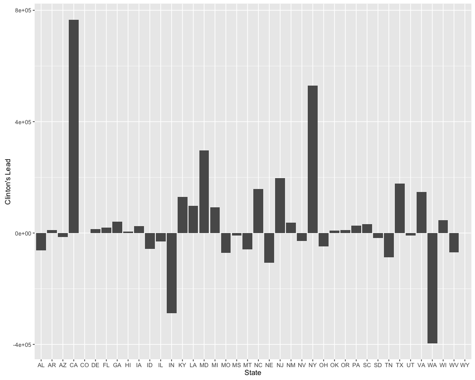

```r
clinton.lead.plot <- ggplot(clinton.lead) +
  geom_bar(aes(x=state_abbreviation, y=clinton.lead), stat='identity') +
  xlab("State") +
  ylab("Clinton's Lead")

clinton.lead.plot
```

### Integrate demographic variables

For each county, plot fraction of votes received against percent white for each candidate

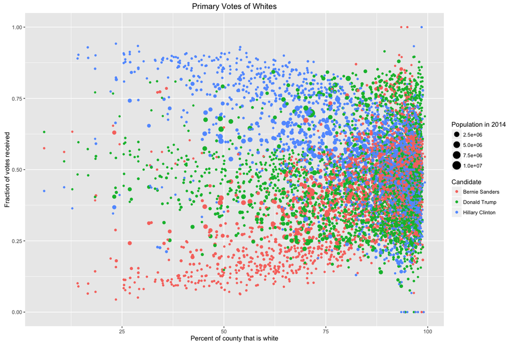

```r
white.plot <- ggplot(election, aes(white, fraction_votes))
white.plot + geom_point(aes(colour = candidate, size=population_2014)) +
  labs(title = "Primary Votes of Whites") +
  xlab("Percent of county that is white") +
  ylab("Fraction of votes received") +
  labs(colour = "Candidate", size = "Population in 2014")
```

So at low percent white (left half of graph), Hillary does best and Bernie does worst at high percent white it’s more of a jumble

Size of point as fraction of vote

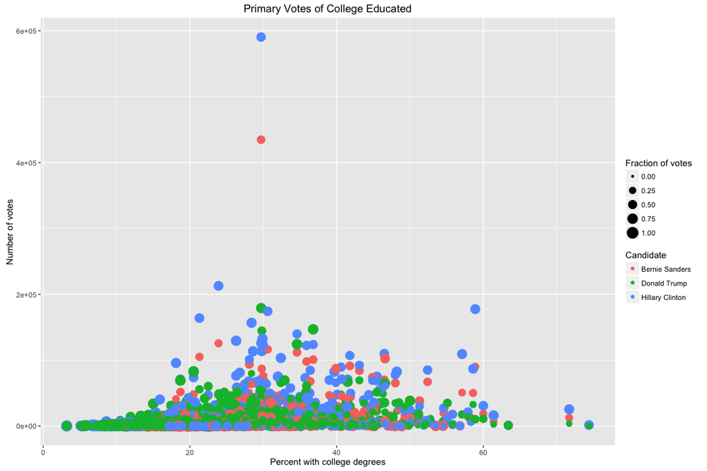

```r
college.plot <- ggplot(election, aes(college, votes))
college.plot + geom_point(aes(colour = candidate, size=fraction_votes)) +
  labs(title = "Primary Votes of College Educated") +
  xlab("Percent with college degrees") +
  ylab("Number of votes") +
  labs(colour = "Candidate", size = "Fraction of votes")
```

What’s up with outlier county with very high population?  
Plot population per county against votes cast per county

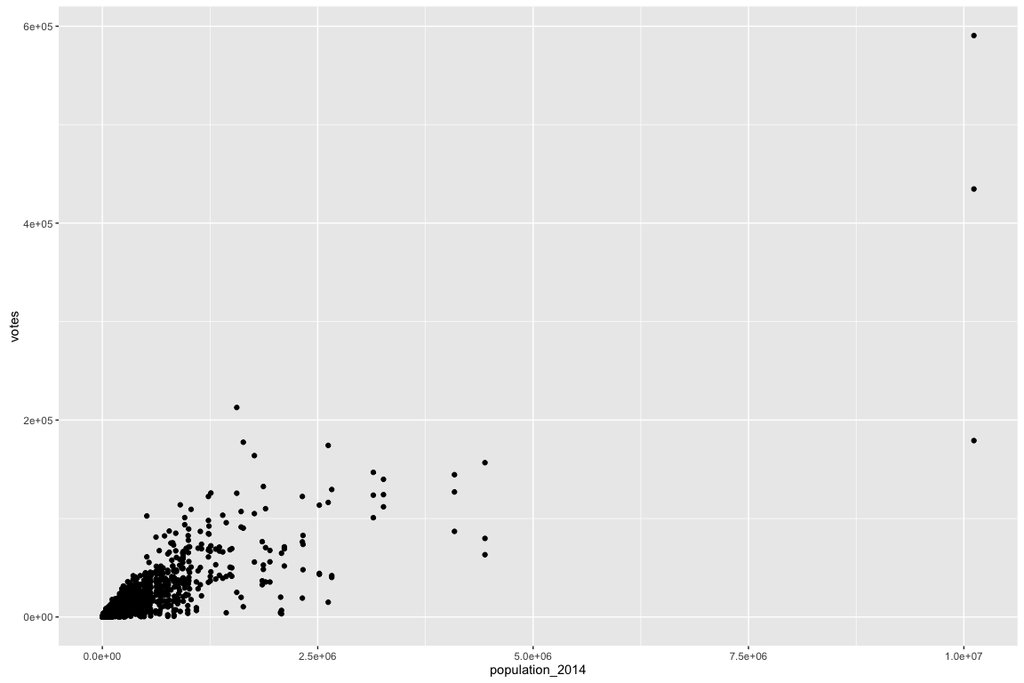

```r
qplot(population_2014, votes, data = election)
```

Looks like there’s also a county that cast a lot of votes  
Find county with highest population

```r
election[which.max(election$population_2014),
         c("fips_county_code", "state", "population_2014")]
```

```
## # A tibble: 1 × 3
##   fips_county_code      state population_2014
##              <dbl>     <fctr>           <dbl>
## 1             6037 California        10116705
```

So the outlier is FIPS code 6037 (LA county).  
According to Google, they are the county with the highest population in the US (9,818,605). Second is Cook County, IL at 5,194,675 (woot)

Take a look at other counties with high populations

```r
find.outliers <- election %>%
  dplyr::select (
    fips_county_code, population_2014,
    state
  ) %>%
  nest() %>%
  select(-data) %>%  # take out column with nested data
  arrange(desc(
    population_2014
  )) %>%
  print(n = 10)
```

```
## # A tibble: 2,798 × 3
##    fips_county_code population_2014      state
##               <dbl>           <dbl>     <fctr>
## 1              6037        10116705 California
## 2             48201         4441370      Texas
## 3              4013         4087191    Arizona
## 4              6073         3263431 California
## 5              6059         3145515 California
## 6             12086         2662874    Florida
## 7             36047         2621793   New York
## 8             48113         2518638      Texas
## 9              6065         2329271 California
## 10            36081         2321580   New York
## # ... with 2,788 more rows
```

### By state

Summarise things by state

```r
election.by.state <- election %>%
  group_by(state_abbreviation, candidate) %>%
  summarise(
    w.b_gap = mean(white - black),           # w.b_gap for white-black gap
    fr.votes = mean(fraction_votes),
    tot.votes = sum(votes),
    percap = mean(inc_percap)
  ) %>%
  ungroup %>%
  arrange(
    percap
  )
```

Spread election by state

```r
election.by.state.spread <- election.by.state %>%
  select (
    state_abbreviation, candidate, tot.votes
  ) %>%
  group_by(candidate) %>%
  spread (
    key = candidate,
    value = tot.votes
  )
kable(election.by.state.spread, format = "markdown")
```

| state_abbreviation | Bernie Sanders | Donald Trump | Hillary Clinton |
| --- | --- | --- | --- |
| AL | 76399 | 371735 | 309928 |
| AR | 64868 | 133144 | 144580 |
| AZ | 163400 | 249916 | 235697 |
| CA | 1502043 | 1174829 | 1940580 |
| CO | 71928 | NA | 49256 |
| DE | 36659 | 42472 | 55950 |
| FL | 566603 | 1077221 | 1097400 |
| GA | 214332 | 501707 | 543008 |
| HI | 23531 | 5677 | 10127 |
| IA | 69452 | 45419 | 69733 |
| ID | 18640 | 62478 | 5065 |
| IL | 452006 | 427086 | 396004 |
| IN | 335256 | 590460 | 303382 |
| KY | 210626 | 82493 | 212550 |
| LA | 72240 | 124818 | 221615 |
| MD | 281275 | 236623 | 533247 |
| MI | 595222 | 483751 | 576795 |
| MO | 309071 | 382093 | 310602 |
| MS | 36348 | 191755 | 182447 |
| MT | 63168 | 114056 | 55194 |
| NC | 460316 | 458151 | 616383 |
| NE | 19120 | 121287 | 14340 |
| NJ | 323259 | 356697 | 554237 |
| NM | 103856 | 73530 | 110451 |
| NV | 5641 | 34531 | 6296 |
| NY | 763469 | 524932 | 1054083 |
| OH | 513549 | 727585 | 679266 |
| OK | 174054 | 130141 | 139338 |
| OR | 320746 | 240804 | 251739 |
| PA | 719955 | 892702 | 918689 |
| SC | 95977 | 239851 | 271514 |
| SD | 25958 | 44866 | 27046 |
| TN | 120333 | 332702 | 245304 |
| TX | 475561 | 757618 | 935080 |
| UT | 61333 | 24864 | 15666 |
| VA | 275507 | 355960 | 503358 |
| WA | 19159 | 403003 | 7140 |
| WI | 567936 | 386370 | 432767 |
| WV | 123860 | 156245 | 86354 |
| WY | 156 | NA | 124 |

Graph per capita income, the white-black gap, and total votes by state for all three candidates

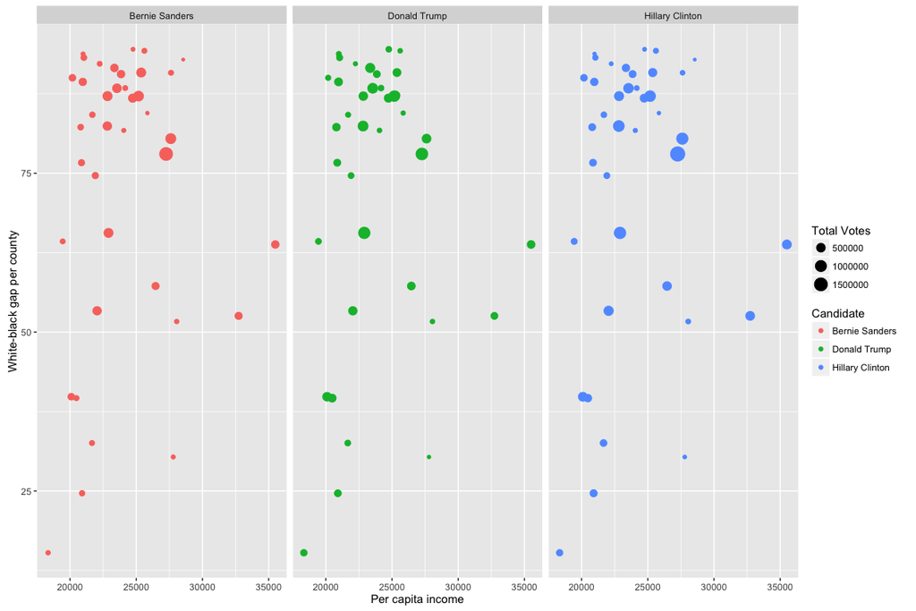

```r
by.state.plot <- ggplot(election.by.state, aes(percap, w.b_gap))
by.state.plot + geom_point(aes(colour = candidate, size=tot.votes)) +
  facet_grid(. ~ candidate) +
  xlab("Per capita income") +
  ylab("White-black gap per county") +
  labs(size="Total Votes", colour = "Candidate")
```